# EasyVisa Project

## Context:

Business communities in the United States are facing high demand for human resources, but one of the constant challenges is identifying and attracting the right talent, which is perhaps the most important element in remaining competitive. Companies in the United States look for hard-working, talented, and qualified individuals both locally as well as abroad.

The Immigration and Nationality Act (INA) of the US permits foreign workers to come to the United States to work on either a temporary or permanent basis. The act also protects US workers against adverse impacts on their wages or working conditions by ensuring US employers' compliance with statutory requirements when they hire foreign workers to fill workforce shortages. The immigration programs are administered by the Office of Foreign Labor Certification (OFLC).

OFLC processes job certification applications for employers seeking to bring foreign workers into the United States and grants certifications in those cases where employers can demonstrate that there are not sufficient US workers available to perform the work at wages that meet or exceed the wage paid for the occupation in the area of intended employment.

## Objective:

In FY 2016, the OFLC processed 775,979 employer applications for 1,699,957 positions for temporary and permanent labor certifications. This was a nine percent increase in the overall number of processed applications from the previous year. The process of reviewing every case is becoming a tedious task as the number of applicants is increasing every year.

The increasing number of applicants every year calls for a Machine Learning based solution that can help in shortlisting the candidates having higher chances of VISA approval. OFLC has hired your firm EasyVisa for data-driven solutions. You as a data scientist have to analyze the data provided and, with the help of a classification model:

- Facilitate the process of visa approvals.
- Recommend a suitable profile for the applicants for whom the visa should be certified or denied based on the drivers that significantly influence the case status.

## Data Description

The data contains the different attributes of the employee and the employer. The detailed data dictionary is given below.

- case_id: ID of each visa application
- continent: Information of continent the employee
- education_of_employee: Information of education of the employee
- has_job_experience: Does the employee has any job experience? Y= Yes; N = No
- requires_job_training: Does the employee require any job training? Y = Yes; N = No
- no_of_employees: Number of employees in the employer's company
- yr_of_estab: Year in which the employer's company was established
- region_of_employment: Information of foreign worker's intended region of employment in the US.
- prevailing_wage: Average wage paid to similarly employed workers in a specific occupation in the area of intended employment. The purpose of the prevailing wage is to ensure that the foreign worker is not underpaid compared to other workers offering the same or similar service in the same area of employment.
- unit_of_wage: Unit of prevailing wage. Values include Hourly, Weekly, Monthly, and Yearly.
- full_time_position: Is the position of work full-time? Y = Full Time Position; N = Part Time Position
- case_status: Flag indicating if the Visa was certified or denied

## Importing necessary libraries and data

```python
# Library to suppress warnings or deprecation notes
import warnings
warnings.filterwarnings('ignore')

# Libraries to help with reading and manipulating data
import numpy as np
import pandas as pd

# Libraries to help with data visualization
import matplotlib.pyplot as plt
%matplotlib inline
import seaborn as sns

# Libraries to split data, impute missing values
from sklearn.model_selection import train_test_split
from sklearn.impute import SimpleImputer

# Libraries to import decision tree classifier and different ensemble classifiers
from sklearn.ensemble import BaggingClassifier
from sklearn.ensemble import RandomForestClassifier
from sklearn.ensemble import AdaBoostClassifier, GradientBoostingClassifier
from xgboost import XGBClassifier
from sklearn.ensemble import StackingClassifier
from sklearn.tree import DecisionTreeClassifier

# Libtune to tune model, get different metric scores
from sklearn import metrics
from sklearn.metrics import confusion_matrix, classification_report, accuracy_score, precision_score, recall_score, f1_score, roc_auc_score
from sklearn.model_selection import GridSearchCV
from sklearn.tree import DecisionTreeRegressor
from sklearn.ensemble import BaggingRegressor,RandomForestRegressor, GradientBoostingRegressor, AdaBoostRegressor, StackingRegressor
from xgboost import XGBRegressor
from sklearn import metrics
random_seed = 1
```

```python
visa = pd.read_csv('EasyVisa.csv')
```

```python
#make a copy of the data to avoid any changes to original
data =visa.copy()
```

## Data Overview

- Observations
- Sanity checks

### Understand the shape and data types

```python
data.shape
```

```
(25480, 12)
```

```python
data.info()
```

```
<class 'pandas.core.frame.DataFrame'>
RangeIndex: 25480 entries, 0 to 25479
Data columns (total 12 columns):
 #   Column                 Non-Null Count  Dtype
---  ------                 --------------  -----
 0   case_id                25480 non-null  object
 1   continent              25480 non-null  object
 2   education_of_employee  25480 non-null  object
 3   has_job_experience     25480 non-null  object
 4   requires_job_training  25480 non-null  object
 5   no_of_employees        25480 non-null  int64
 6   yr_of_estab            25480 non-null  int64
 7   region_of_employment   25480 non-null  object
 8   prevailing_wage        25480 non-null  float64
 9   unit_of_wage           25480 non-null  object
 10  full_time_position     25480 non-null  object
 11  case_status            25480 non-null  object
dtypes: float64(1), int64(2), object(9)
memory usage: 2.3+ MB
```

- no missing values
- data types are mostly string/object type with some numeric

### View first 5 rows and last 5 rows

```python
data.head()
```

|  | case_id | continent | education_of_employee | has_job_experience | requires_job_training | no_of_employees | yr_of_estab | region_of_employment | prevailing_wage | unit_of_wage | full_time_position | case_status |
| --- | --- | --- | --- | --- | --- | --- | --- | --- | --- | --- | --- | --- |
| 0 | EZYV01 | Asia | High School | N | N | 14513 | 2007 | West | 592.2029 | Hour | Y | Denied |
| 1 | EZYV02 | Asia | Master's | Y | N | 2412 | 2002 | Northeast | 83425.6500 | Year | Y | Certified |
| 2 | EZYV03 | Asia | Bachelor's | N | Y | 44444 | 2008 | West | 122996.8600 | Year | Y | Denied |
| 3 | EZYV04 | Asia | Bachelor's | N | N | 98 | 1897 | West | 83434.0300 | Year | Y | Denied |
| 4 | EZYV05 | Africa | Master's | Y | N | 1082 | 2005 | South | 149907.3900 | Year | Y | Certified |

```python
data.tail()
```

|  | case_id | continent | education_of_employee | has_job_experience | requires_job_training | no_of_employees | yr_of_estab | region_of_employment | prevailing_wage | unit_of_wage | full_time_position | case_status |
| --- | --- | --- | --- | --- | --- | --- | --- | --- | --- | --- | --- | --- |
| 25475 | EZYV25476 | Asia | Bachelor's | Y | Y | 2601 | 2008 | South | 77092.57 | Year | Y | Certified |
| 25476 | EZYV25477 | Asia | High School | Y | N | 3274 | 2006 | Northeast | 279174.79 | Year | Y | Certified |
| 25477 | EZYV25478 | Asia | Master's | Y | N | 1121 | 1910 | South | 146298.85 | Year | N | Certified |
| 25478 | EZYV25479 | Asia | Master's | Y | Y | 1918 | 1887 | West | 86154.77 | Year | Y | Certified |
| 25479 | EZYV25480 | Asia | Bachelor's | Y | N | 3195 | 1960 | Midwest | 70876.91 | Year | Y | Certified |

### Summary of dataset

```python
data.describe()
```

|  | no_of_employees | yr_of_estab | prevailing_wage |
| --- | --- | --- | --- |
| count | 25480.000000 | 25480.000000 | 25480.000000 |
| mean | 5667.043210 | 1979.409929 | 74455.814592 |
| std | 22877.928848 | 42.366929 | 52815.942327 |
| min | -26.000000 | 1800.000000 | 2.136700 |
| 25% | 1022.000000 | 1976.000000 | 34015.480000 |
| 50% | 2109.000000 | 1997.000000 | 70308.210000 |
| 75% | 3504.000000 | 2005.000000 | 107735.512500 |
| max | 602069.000000 | 2016.000000 | 319210.270000 |

- no_of_employees minimum is -26, which can not be possible. This column may be altered a little bit to cutoff at 1 employee.
- we can change prevailing_wage to an int64 type from a float for ease and cutoff at 2 decimals.

```python
# categorical summary
data.describe(include=["object"])
```

|  | case_id | continent | education_of_employee | has_job_experience | requires_job_training | region_of_employment | unit_of_wage | full_time_position | case_status |
| --- | --- | --- | --- | --- | --- | --- | --- | --- | --- |
| count | 25480 | 25480 | 25480 | 25480 | 25480 | 25480 | 25480 | 25480 | 25480 |
| unique | 25480 | 6 | 4 | 2 | 2 | 5 | 4 | 2 | 2 |
| top | EZYV11607 | Asia | Bachelor's | Y | N | Northeast | Year | Y | Certified |
| freq | 1 | 16861 | 10234 | 14802 | 22525 | 7195 | 22962 | 22773 | 17018 |

- case_id has 25480 unique values. We can delete that column as it does not add value.

```python
# check for duplicate values
data[data.duplicated()].count()
```

```
case_id                  0
continent                0
education_of_employee    0
has_job_experience       0
requires_job_training    0
no_of_employees          0
yr_of_estab              0
region_of_employment     0
prevailing_wage          0
unit_of_wage             0
full_time_position       0
case_status              0
dtype: int64
```

- no duplicate values

```python
# dropping case_id from dataframe
data.drop(columns=['case_id'], inplace=True)
```

```python
# check breakdown of categorical columns
cat_columns = ['continent','education_of_employee','has_job_experience',
              'requires_job_training','region_of_employment','unit_of_wage',
              'full_time_position','case_status']
for i in cat_columns:
    print(data[i].value_counts())
    print("*" * 50)
```

```
Asia             16861
Europe            3732
North America     3292
South America      852
Africa             551
Oceania            192
Name: continent, dtype: int64
Bachelor's     10234
Master's        9634
High School     3420
Doctorate       2192
Name: education_of_employee, dtype: int64
Y    14802
N    10678
Name: has_job_experience, dtype: int64
N    22525
Y     2955
Name: requires_job_training, dtype: int64
Northeast    7195
South        7017
West         6586
Midwest      4307
Island        375
Name: region_of_employment, dtype: int64
Year     22962
Hour      2157
Week       272
Month       89
Name: unit_of_wage, dtype: int64
Y    22773
N     2707
Name: full_time_position, dtype: int64
Certified    17018
Denied        8462
Name: case_status, dtype: int64
```

## Exploratory Data Analysis (EDA)

- EDA is an important part of any project involving data.
- It is important to investigate and understand the data better before building a model with it.
- A few questions have been mentioned below which will help you approach the analysis in the right manner and generate insights from the data.
- A thorough analysis of the data, in addition to the questions mentioned below, should be done.

### Univariate Analysis

```python
def histogram_boxplot(data, feature, figsize=(15, 10), kde=False, bins=None):
    """
    Boxplot and histogram combined

    data: dataframe
    feature: dataframe column
    figsize: size of figure (default (15,10))
    kde: whether to show the density curve (default False)
    bins: number of bins for histogram (default None)
    """
    f2, (ax_box2, ax_hist2) = plt.subplots(
        nrows=2,  # Number of rows of the subplot grid= 2
        sharex=True,  # x-axis will be shared among all subplots
        gridspec_kw={"height_ratios": (0.25, 0.75)},
        figsize=figsize,
    )  # creating the 2 subplots
    sns.boxplot(
        data=data, x=feature, ax=ax_box2, showmeans=True, color="violet"
    )  # boxplot will be created and a star will indicate the mean value of the column
    sns.histplot(
        data=data, x=feature, kde=kde, ax=ax_hist2, bins=bins, palette="winter"
    ) if bins else sns.histplot(
        data=data, x=feature, kde=kde, ax=ax_hist2
    )  # For histogram
    ax_hist2.axvline(
        data[feature].mean(), color="green", linestyle="--"
    )  # Add mean to the histogram
    ax_hist2.axvline(
        data[feature].median(), color="black", linestyle="-"
    )  # Add median to the histogram
```

### Observations on no_of_employees

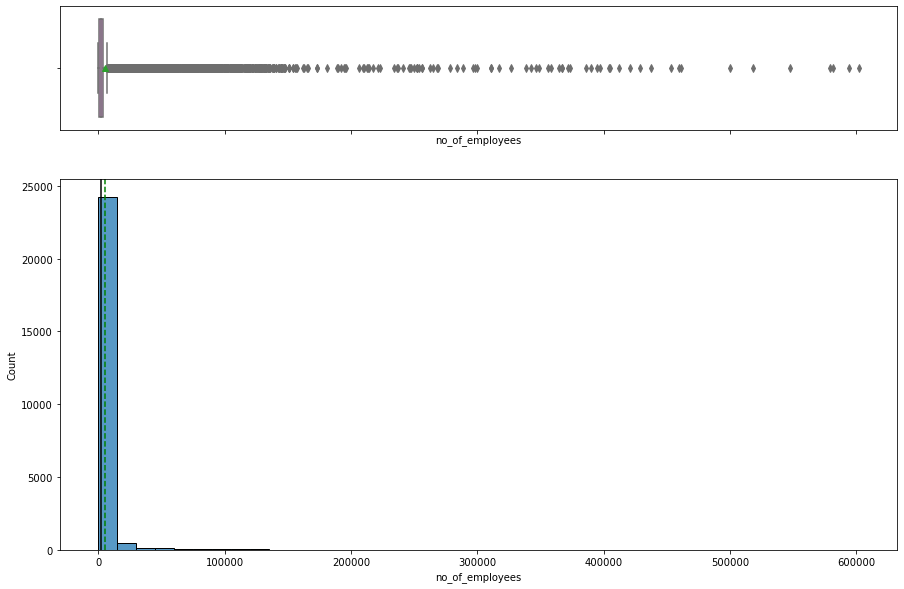

```python
histogram_boxplot(data,'no_of_employees', bins = 40)
```

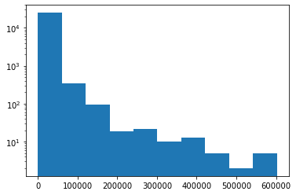

```python
#log plot
plt.hist(data['no_of_employees'], log=True)
```

```python
data[data['no_of_employees'] < 0].count()
```

```
continent                33
education_of_employee    33
has_job_experience       33
requires_job_training    33
no_of_employees          33
yr_of_estab              33
region_of_employment     33
prevailing_wage          33
unit_of_wage             33
full_time_position       33
case_status              33
dtype: int64
```

```python
data[data['no_of_employees']<0]
```

|  | continent | education_of_employee | has_job_experience | requires_job_training | no_of_employees | yr_of_estab | region_of_employment | prevailing_wage | unit_of_wage | full_time_position | case_status |
| --- | --- | --- | --- | --- | --- | --- | --- | --- | --- | --- | --- |
| 245 | Europe | Master's | N | N | -25 | 1980 | Northeast | 39452.9900 | Year | Y | Certified |
| 378 | Asia | Bachelor's | N | Y | -11 | 2011 | Northeast | 32506.1400 | Year | Y | Denied |
| 832 | South America | Master's | Y | N | -17 | 2002 | South | 129701.9400 | Year | Y | Certified |
| 2918 | Asia | Master's | Y | N | -26 | 2005 | Midwest | 112799.4600 | Year | Y | Certified |
| 6439 | Asia | Bachelor's | N | N | -14 | 2013 | South | 103.9700 | Hour | Y | Denied |
| 6634 | Asia | Bachelor's | Y | N | -26 | 1923 | West | 5247.3200 | Year | Y | Denied |
| 7224 | Europe | Doctorate | N | N | -25 | 1998 | Midwest | 141435.9500 | Year | Y | Certified |
| 7281 | Asia | High School | N | N | -14 | 2000 | Midwest | 58488.5000 | Year | Y | Denied |
| 7318 | Asia | Bachelor's | Y | Y | -26 | 2006 | South | 115005.6100 | Year | Y | Certified |
| 7761 | Asia | Master's | N | N | -11 | 2009 | Midwest | 38457.5100 | Year | Y | Certified |
| 9872 | Europe | Master's | Y | N | -26 | 1996 | South | 37397.0500 | Year | Y | Certified |
| 11493 | Asia | High School | Y | N | -14 | 1999 | South | 27599.3500 | Year | Y | Denied |
| 13471 | North America | Master's | N | N | -17 | 2003 | Northeast | 257.2413 | Hour | Y | Denied |
| 14022 | Asia | Bachelor's | N | Y | -11 | 1946 | Northeast | 108403.5600 | Year | Y | Certified |
| 14146 | Asia | Bachelor's | N | Y | -26 | 1954 | West | 81982.2700 | Year | Y | Certified |
| 14726 | Asia | Master's | N | N | -11 | 2000 | Midwest | 167851.8000 | Year | Y | Certified |
| 15600 | Asia | Bachelor's | N | N | -14 | 2014 | South | 24641.6100 | Year | Y | Denied |
| 15859 | Asia | High School | N | N | -11 | 1969 | South | 44640.6000 | Year | Y | Denied |
| 16157 | Asia | Master's | Y | N | -11 | 1994 | South | 62681.2500 | Year | Y | Certified |
| 16883 | North America | Bachelor's | Y | N | -26 | 1968 | Northeast | 168.1558 | Hour | Y | Denied |
| 17006 | Asia | Doctorate | Y | N | -11 | 1984 | West | 25753.5100 | Year | Y | Denied |
| 17655 | North America | Bachelor's | Y | N | -17 | 2007 | Northeast | 129753.1800 | Year | Y | Denied |
| 17844 | Asia | Bachelor's | N | N | -14 | 2012 | West | 29325.8500 | Year | Y | Denied |
| 17983 | Asia | Bachelor's | N | N | -26 | 2004 | South | 84359.9800 | Year | Y | Denied |
| 20815 | Asia | Bachelor's | N | Y | -17 | 1990 | West | 91897.5700 | Year | Y | Certified |
| 20984 | Europe | Doctorate | Y | N | -14 | 1989 | Midwest | 37012.8000 | Year | Y | Certified |
| 21255 | North America | High School | N | N | -25 | 1987 | South | 99405.4700 | Year | N | Denied |
| 21760 | Asia | Bachelor's | Y | N | -25 | 2000 | West | 100463.5800 | Year | Y | Certified |
| 21944 | Africa | Master's | Y | N | -25 | 1977 | Midwest | 79150.5100 | Year | Y | Certified |
| 22084 | North America | Bachelor's | Y | N | -14 | 1980 | West | 691.0609 | Hour | Y | Denied |
| 22388 | Asia | Master's | Y | N | -14 | 1986 | South | 17893.1100 | Year | Y | Certified |
| 23186 | Asia | Master's | N | Y | -11 | 2007 | Midwest | 120195.3500 | Year | Y | Certified |
| 23476 | Europe | Master's | Y | N | -11 | 2000 | West | 95072.7500 | Year | Y | Denied |

- very heavily right skewed which we saw during the summary.
- Over 75% of applicants come from companies with less than 4,000 employees.
- 33 applicants stating number of employees is negative. This data will have to be altered.
- In the grand scheme of things it may be acceptable to remove those with negative employee numbers considering there are over 25,000 other applicants for modeling.

### Observations on yr_of_estab

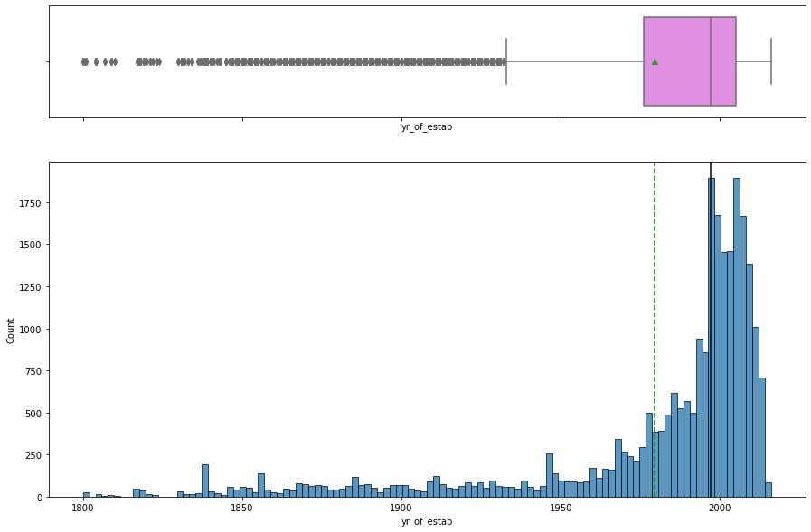

```python
histogram_boxplot(data,'yr_of_estab')
```

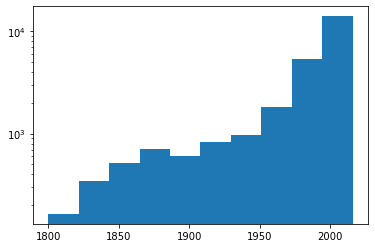

```python
#log plot
plt.hist(data['yr_of_estab'], log=True)
```

### Observations on Prevailing_wage

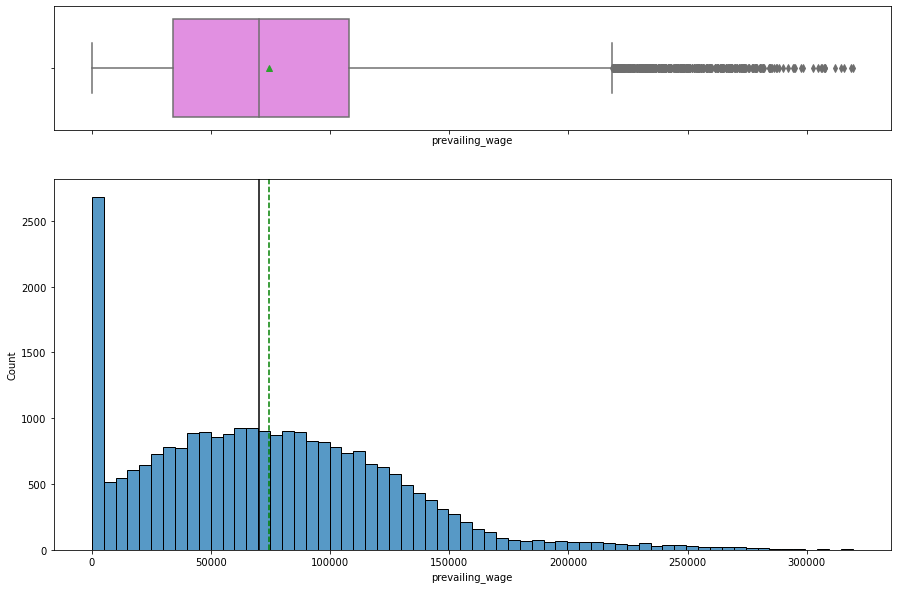

```python
histogram_boxplot(data,'prevailing_wage')
```

```python
data.prevailing_wage.describe()
```

```
count     25480.000000
mean      74455.814592
std       52815.942327
min           2.136700
25%       34015.480000
50%       70308.210000
75%      107735.512500
max      319210.270000
Name: prevailing_wage, dtype: float64
```

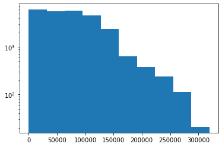

```python
#log plot
plt.hist(data['prevailing_wage'], log=True)
```

- Wage is very heavily right skewed.
- Min of $2 and a max of 300k. (assuming wage is in American Dollar as data is not specific.)

```python
# function to create labeled barplots


def labeled_barplot(data, feature, perc=False, n=None):
    """
    Barplot with percentage at the top

    data: dataframe
    feature: dataframe column
    perc: whether to display percentages instead of count (default is False)
    n: displays the top n category levels (default is None, i.e., display all levels)
    """

    total = len(data[feature])  # length of the column
    count = data[feature].nunique()
    if n is None:
        plt.figure(figsize=(count + 2, 6))
    else:
        plt.figure(figsize=(n + 2, 6))

    plt.xticks(rotation=90, fontsize=15)
    ax = sns.countplot(
        data=data,
        x=feature,
        palette="Paired",
        order=data[feature].value_counts().index[:n].sort_values(),
    )

    for p in ax.patches:
        if perc == True:
            label = "{:.1f}%".format(
                100 * p.get_height() / total
            )  # percentage of each class of the category
        else:
            label = p.get_height()  # count of each level of the category

        x = p.get_x() + p.get_width() / 2  # width of the plot
        y = p.get_height()  # height of the plot

        ax.annotate(
            label,
            (x, y),
            ha="center",
            va="center",
            size=12,
            xytext=(0, 5),
            textcoords="offset points",
        )  # annotate the percentage

    plt.show()  # show the plot
```

### Observations on Continent

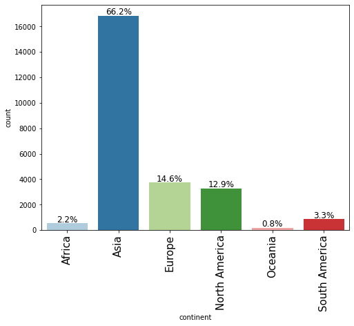

```python
labeled_barplot(data,'continent', perc = True)
```

- 66.2% of visa applicants are from Asia
- Oceania has the lowest number of applicants

### Observations on Education_of_employee

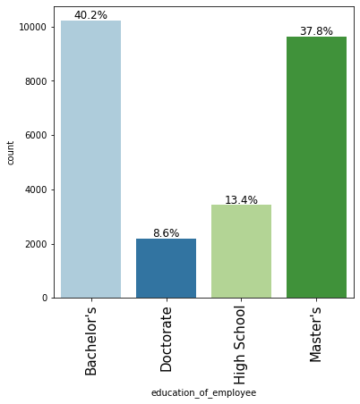

```python
labeled_barplot(data,'education_of_employee', perc = True)
```

- 40.2% of applicants have a Bachelor's degree while 37.8% have a Master's degree
- This data does no identify whether it is the highest attained education (which it probably is, but do not know for sure).

### Observations on has_job_experience

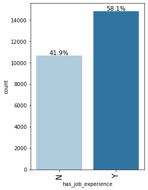

```python
labeled_barplot(data,'has_job_experience',perc=True)
```

- 58.1% of applicants have job experience, but no further information regarding what kind of experience or whether is is applicable experience for job they are applying to.

### Observations on requires_job_training

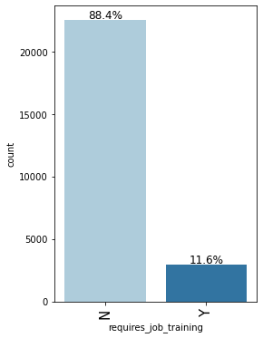

```python
labeled_barplot(data, 'requires_job_training', perc=True)
```

- 88.4% of applicants do not require job training

### Observations on region_of_employment

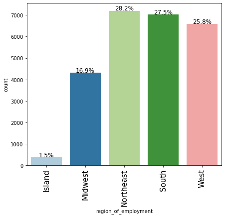

```python
labeled_barplot(data,'region_of_employment', perc = True)
```

- 28.2% of applicants intend to find a job in the Northeast. The majority of applicants appear to be applying to positions near the largest cities (Coastal areas).
- 1.5% are applying for work on Islands (Hawaii and US territories?)

### Observations on unit_of_wage

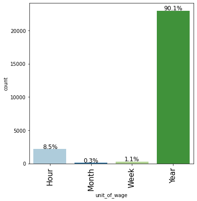

```python
labeled_barplot(data,'unit_of_wage', perc = True)
```

- 90.1% of applicants have annual salaries.
- This data could affect interpretation of prevailing_wage as an hourly wage compared to an annual wage would heavily skew the data.

### Observations on full_time_position

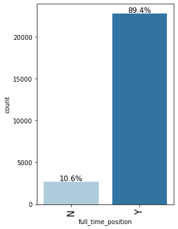

```python
labeled_barplot(data,'full_time_position',perc=True)
```

- 89.4% of applicants are applying to full time positions.

### Observations on case_status

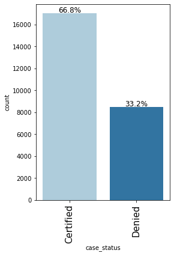

```python
labeled_barplot(data,'case_status',perc=True)
```

- 66.8% of the applicants recieved a Visa

### Bivariate Analysis

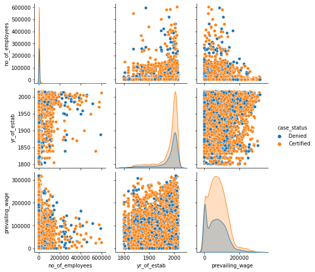

```python
sns.pairplot(data=data, hue='case_status')
plt.show()
```

- As yr_of_estab increases so to does the number of employees.
- The prevailing wage is higher in smaller companies

**Questions**:

1. Those with higher education may want to travel abroad for a well-paid job. Does education play a role in Visa certification?
2. How does the visa status vary across different continents?
3. Experienced professionals might look abroad for opportunities to improve their lifestyles and career development. Does work experience influence visa status?
4. In the United States, employees are paid at different intervals. Which pay unit is most likely to be certified for a visa?
5. The US government has established a prevailing wage to protect local talent and foreign workers. How does the visa status change with the prevailing wage?

### Observation of Educations vs Case Status

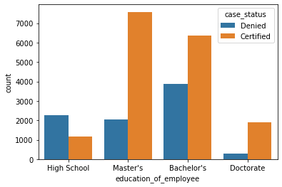

```python
sns.countplot(x='education_of_employee', hue='case_status',data = data)
```

- it does appear that higher educations does increase liklihood of attaining a Visa.
- The higher the education level the greater the chance of getting a Visa

### Observations Visa status and Home Continents

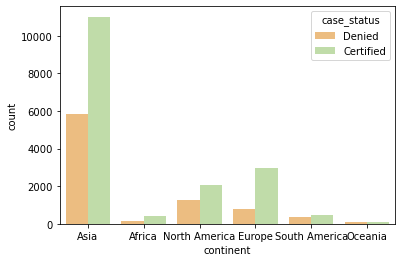

```python
sns.countplot(x='continent', hue= 'case_status', data = data, palette = 'Spectral')
```

```python
data.groupby('continent')['case_status'].value_counts()
```

```
continent      case_status
Africa         Certified        397
               Denied           154
Asia           Certified      11012
               Denied          5849
Europe         Certified       2957
               Denied           775
North America  Certified       2037
               Denied          1255
Oceania        Certified        122
               Denied            70
South America  Certified        493
               Denied           359
Name: case_status, dtype: int64
```

### Observations on Continent and Education of Employee

```python
data.groupby('continent')['education_of_employee'].value_counts()
```

```
continent      education_of_employee
Africa         Master's                  288
               Bachelor's                143
               High School                66
               Doctorate                  54
Asia           Bachelor's               7168
               Master's                 6480
               High School              2290
               Doctorate                 923
Europe         Bachelor's               1299
               Master's                 1097
               Doctorate                 846
               High School               490
North America  Master's                 1408
               Bachelor's               1225
               High School               401
               Doctorate                 258
Oceania        Master's                   68
               Bachelor's                 66
               High School                36
               Doctorate                  22
South America  Bachelor's                333
               Master's                  293
               High School               137
               Doctorate                  89
Name: education_of_employee, dtype: int64
```

### Observations on Work Experience vs Visa Status

```python
data.groupby('has_job_experience')['case_status'].value_counts()
```

```
has_job_experience  case_status
N                   Certified       5994
                    Denied          4684
Y                   Certified      11024
                    Denied          3778
Name: case_status, dtype: int64
```

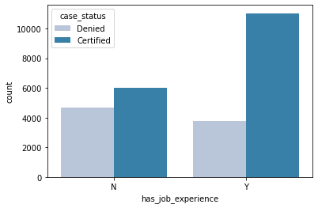

```python
sns.countplot(x='has_job_experience', hue= 'case_status', data = data, palette = 'PuBu')
```

- Having job experience dramatically improves chances of getting a Visa from close to 50% with no job experience to almost 75% with job experience.
- But, standing alone does the job experience apply to the position they are trying to get the Visa for, or a different line of work entirely?

### Observations on Pay Interval vs Visa Status

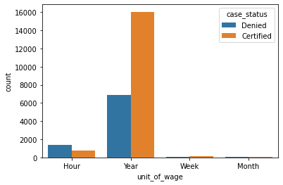

```python
sns.countplot(x="unit_of_wage", hue ='case_status', data = data)
```

```python
data.groupby('unit_of_wage')['case_status'].describe()
```

| unit_of_wage | count | unique | top | freq |
| --- | --- | --- | --- | --- |
| Hour | 2157 | 2 | Denied | 1410 |
| Month | 89 | 2 | Certified | 55 |
| Week | 272 | 2 | Certified | 169 |
| Year | 22962 | 2 | Certified | 16047 |

```python
data.groupby('unit_of_wage')['case_status'].value_counts()
```

```
unit_of_wage  case_status
Hour          Denied          1410
              Certified        747
Month         Certified         55
              Denied            34
Week          Certified        169
              Denied           103
Year          Certified      16047
              Denied          6915
Name: case_status, dtype: int64
```

### Observations on Prevailing_wage vs. Visa Status

```python
data.groupby('case_status')['prevailing_wage'].describe()
```

| case_status | count | mean | std | min | 25% | 50% | 75% | max |
| --- | --- | --- | --- | --- | --- | --- | --- | --- |
| Certified | 17018.0 | 77293.619243 | 52042.715576 | 2.1367 | 38375.330 | 72486.27 | 108879.1075 | 318446.05 |
| Denied | 8462.0 | 68748.681580 | 53890.166031 | 2.9561 | 23497.295 | 65431.46 | 105097.6400 | 319210.27 |

- The prevailing_wage is very similar for both certified and denied applicants.

### Observations on Education and Unit of Wage

```python
data.groupby('education_of_employee')['unit_of_wage'].value_counts()
```

```
education_of_employee  unit_of_wage
Bachelor's             Year            9086
                       Hour             981
                       Week             126
                       Month             41
Doctorate              Year            2083
                       Hour              96
                       Week               8
                       Month              5
High School            Year            2980
                       Hour             395
                       Week              32
                       Month             13
Master's               Year            8813
                       Hour             685
                       Week             106
                       Month             30
Name: unit_of_wage, dtype: int64
```

- All education levels have highest number of applicants with yearly wage.

### Observations on Education and Continent

```python
data.groupby('education_of_employee')['continent'].value_counts()
```

```
education_of_employee  continent
Bachelor's             Asia             7168
                       Europe           1299
                       North America    1225
                       South America     333
                       Africa            143
                       Oceania            66
Doctorate              Asia              923
                       Europe            846
                       North America     258
                       South America      89
                       Africa             54
                       Oceania            22
High School            Asia             2290
                       Europe            490
                       North America     401
                       South America     137
                       Africa             66
                       Oceania            36
Master's               Asia             6480
                       North America    1408
                       Europe           1097
                       South America     293
                       Africa            288
                       Oceania            68
Name: continent, dtype: int64
```

- All levels of education have yearly unit of wage as the highest count.
- All levels of education follow the same trend in the units of wage with year being the most prevalent, followed by hour, week and then month.

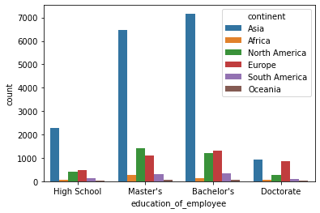

```python
sns.countplot(x="education_of_employee", hue ='continent', data = data)
```

- Asia is represented the most across all education levels.

### Observations on Job Training and Job Experience

```python
data.groupby('requires_job_training')['has_job_experience'].value_counts()
```

```
requires_job_training  has_job_experience
N                      Y                     13537
                       N                      8988
Y                      N                      1690
                       Y                      1265
Name: has_job_experience, dtype: int64
```

- Those with job experience do not require on the job training, which can reduce cost for employers.
- Those that require job training are almost split 50/50 on whether they have job experience or not, so job experience may not be related to the work they are applying for.

### Observations on Full time positions and Case Status

```python
data.groupby('full_time_position')['case_status'].value_counts()
```

```
full_time_position  case_status
N                   Certified       1855
                    Denied           852
Y                   Certified      15163
                    Denied          7610
Name: case_status, dtype: int64
```

### Summary of EDA

**Data Description:**

- Dependent variable is "case_status" which is representing whether an applicant was declined or certified for a work Visa, and it is of object data type.
- Most of the independent variables are of object data type.
- There are no missing values in the dataset.

**Data Cleaning:**

- Case_ID is an ID variable so it is dropped from the data as it will not bring any value to the model.
- There are some negative values in no_of_employees, which can not be true, so this will be remedied in pre-model processing.

## Data Preprocessing

- Missing value treatment (if needed)
- Feature engineering
- Outlier detection and treatment (if needed)
- Preparing data for modeling
- Any other preprocessing steps (if needed)
- Data has no missing values
- no_of_employees will be adjusted to remove those rows with a negative values for number of employees

```python
# making copy of dataframe
df = data.copy()
```

```python
#removing rows with negative values for number of employees
df.drop(df[df['no_of_employees'] <0].index, inplace = True)
print("original")
print(data.no_of_employees.describe())
print("*" * 50)
print("cleaned")
print(df.no_of_employees.describe())
```

```
original
count     25480.000000
mean       5667.043210
std       22877.928848
min         -26.000000
25%        1022.000000
50%        2109.000000
75%        3504.000000
max      602069.000000
Name: no_of_employees, dtype: float64
cleaned
count     25447.000000
mean       5674.415334
std       22891.842245
min          12.000000
25%        1025.000000
50%        2112.000000
75%        3506.500000
max      602069.000000
Name: no_of_employees, dtype: float64
```

- minimum value has been changed from a negative to a value of 12 which makes much more sense.
- using the median value (which is fairly high) was decided against as the total negative entries was very small in comparison to the large data set.
- There was minimum effect to the data, which is good.

## Splitting Data

```python
df.info()
```

```
<class 'pandas.core.frame.DataFrame'>
Int64Index: 25447 entries, 0 to 25479
Data columns (total 11 columns):
 #   Column                 Non-Null Count  Dtype
---  ------                 --------------  -----
 0   continent              25447 non-null  object
 1   education_of_employee  25447 non-null  object
 2   has_job_experience     25447 non-null  object
 3   requires_job_training  25447 non-null  object
 4   no_of_employees        25447 non-null  int64
 5   yr_of_estab            25447 non-null  int64
 6   region_of_employment   25447 non-null  object
 7   prevailing_wage        25447 non-null  float64
 8   unit_of_wage           25447 non-null  object
 9   full_time_position     25447 non-null  object
 10  case_status            25447 non-null  object
dtypes: float64(1), int64(2), object(8)
memory usage: 2.3+ MB
```

```python
#changing case_status to int format 0/1
df["case_status"] = df["case_status"].replace(['Denied'], 0)#.astype(int)
df["case_status"] = df["case_status"].replace(['Certified'], 1)#.astype(int)
df.case_status.value_counts()
```

```
1    17001
0     8446
Name: case_status, dtype: int64
```

```python
# dropping the y variable
X = df.drop('case_status',axis=1)
y = df['case_status']
```

```python
# changing categorical to dummy columns
# categorical splitting
X = pd.get_dummies(
    X,
    columns=X.select_dtypes(include=["object"]).columns.tolist(),
    drop_first=True,
)
X.head()
```

|  | no_of_employees | yr_of_estab | prevailing_wage | continent_Asia | continent_Europe | continent_North America | continent_Oceania | continent_South America | education_of_employee_Doctorate | education_of_employee_High School | ... | has_job_experience_Y | requires_job_training_Y | region_of_employment_Midwest | region_of_employment_Northeast | region_of_employment_South | region_of_employment_West | unit_of_wage_Month | unit_of_wage_Week | unit_of_wage_Year | full_time_position_Y |
| --- | --- | --- | --- | --- | --- | --- | --- | --- | --- | --- | --- | --- | --- | --- | --- | --- | --- | --- | --- | --- | --- |
| 0 | 14513 | 2007 | 592.2029 | 1 | 0 | 0 | 0 | 0 | 0 | 1 | ... | 0 | 0 | 0 | 0 | 0 | 1 | 0 | 0 | 0 | 1 |
| 1 | 2412 | 2002 | 83425.6500 | 1 | 0 | 0 | 0 | 0 | 0 | 0 | ... | 1 | 0 | 0 | 1 | 0 | 0 | 0 | 0 | 1 | 1 |
| 2 | 44444 | 2008 | 122996.8600 | 1 | 0 | 0 | 0 | 0 | 0 | 0 | ... | 0 | 1 | 0 | 0 | 0 | 1 | 0 | 0 | 1 | 1 |
| 3 | 98 | 1897 | 83434.0300 | 1 | 0 | 0 | 0 | 0 | 0 | 0 | ... | 0 | 0 | 0 | 0 | 0 | 1 | 0 | 0 | 1 | 1 |
| 4 | 1082 | 2005 | 149907.3900 | 0 | 0 | 0 | 0 | 0 | 0 | 0 | ... | 1 | 0 | 0 | 0 | 1 | 0 | 0 | 0 | 1 | 1 |

5 rows × 21 columns

```python
# Splitting data into training and test set:
X_train, X_test, y_train, y_test = train_test_split(X, y, test_size=0.3, random_state=1,stratify=y)
print(X_train.shape, X_test.shape)
```

```
(17812, 21) (7635, 21)
```

```python
print('Training')
print(y_train.value_counts(1))
print("*" * 50)
print('Test')
print(y_test.value_counts(1))
```

```
Training
1    0.668089
0    0.331911
Name: case_status, dtype: float64
Test
1    0.668107
0    0.331893
Name: case_status, dtype: float64
```

## Model evaluation criterion

### The model can make wrong predictions as:

1. Predicting an applicant should receive a work Visa when they should be declined.
2. Predicting an applicant should not receive a work Visa when they should be Certified.

### Which case is more important?

1. If the model predicts an applicant should be certified but should be declined then the company that sponsors them could be creating more expense in training, and potentially overpay the employee and lose out on other valid candidates.
2. If the model predicts an applicant should be declined but in reality they should be certified then the company would lose out on filling potential vacancies in the work force and aiding in increasing company profit.

### Which metric to optimize?

- We would want F1-Score to be maximized, the greater the F1-Score higher the chances of predicting both the classes correctly.

## Building bagging and boosting models

```python
# defining a function to compute different metrics to check performance of a classification model built using sklearn
def model_performance_classification_sklearn(model, predictors, target):
    """
    Function to compute different metrics to check classification model performance

    model: classifier
    predictors: independent variables
    target: dependent variable
    """

    # predicting using the independent variables
    pred = model.predict(predictors)

    acc = accuracy_score(target, pred)  # to compute Accuracy
    recall = recall_score(target, pred)  # to compute Recall
    precision = precision_score(target, pred)  # to compute Precision
    f1 = f1_score(target, pred)  # to compute F1-score

    # creating a dataframe of metrics
    df_perf = pd.DataFrame(
        {
            "Accuracy": acc,
            "Recall": recall,
            "Precision": precision,
            "F1": f1,
        },
        index=[0],
    )

    return df_perf
```

```python
def confusion_matrix_sklearn(model, predictors, target):
    """
    To plot the confusion_matrix with percentages

    model: classifier
    predictors: independent variables
    target: dependent variable
    """
    y_pred = model.predict(predictors)
    cm = confusion_matrix(target, y_pred)
    labels = np.asarray(
        [
            ["{0:0.0f}".format(item) + "\n{0:.2%}".format(item / cm.flatten().sum())]
            for item in cm.flatten()
        ]
    ).reshape(2, 2)

    plt.figure(figsize=(6, 4))
    sns.heatmap(cm, annot=labels, fmt="")
    plt.ylabel("True label")
    plt.xlabel("Predicted label")
```

### Decision Tree

```python
dtree=DecisionTreeRegressor(random_state=1)
dtree.fit(X_train,y_train)
```

```
DecisionTreeRegressor(random_state=1)
```

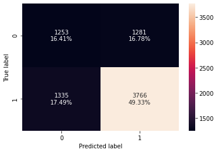

```python
#Creating confusion matrix
confusion_matrix_sklearn(dtree,X_test,y_test)
```

```python
dtree_model_train_perf=model_performance_classification_sklearn(dtree,X_train,y_train)
print("Training performance:\n",dtree_model_train_perf)
dtree_model_test_perf=model_performance_classification_sklearn(dtree,X_test,y_test)
print("Testing performance:\n",dtree_model_test_perf)
```

```
Training performance:
    Accuracy  Recall  Precision   F1
0       1.0     1.0        1.0  1.0
Testing performance:
    Accuracy    Recall  Precision        F1
0  0.657367  0.738287   0.746186  0.742215
```

- Decision tree is overfitting the training data with the perfect metrics.

## Bagging Classifier

```
Training performance:
    Accuracy    Recall  Precision        F1
0  0.984673  0.985882    0.99113  0.988499
Testing performance:
    Accuracy    Recall  Precision       F1
0  0.701244  0.779259   0.774854  0.77705
```

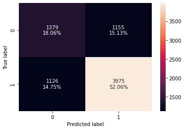

```python
#Fitting the model
bagging_classifier = BaggingClassifier(random_state=1)
bagging_classifier.fit(X_train,y_train)

#Calculating different metrics
bagging_classifier_model_train_perf=model_performance_classification_sklearn(bagging_classifier,X_train,y_train)
print("Training performance:\n",bagging_classifier_model_train_perf)
bagging_classifier_model_test_perf=model_performance_classification_sklearn(bagging_classifier,X_test,y_test)
print("Testing performance:\n",bagging_classifier_model_test_perf)
#Creating confusion matrix
confusion_matrix_sklearn(bagging_classifier, X_test, y_test)
```

- Bagging Classifier is still overfitting the training data, but not as much as the Decision Tree.

### Random Forest

```
Training performance:
    Accuracy  Recall  Precision   F1
0       1.0     1.0        1.0  1.0
Testing performance:
    Accuracy    Recall  Precision        F1
0  0.721022  0.832974   0.768771  0.799586
```

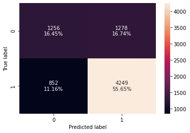

```python
#Fitting the model
rf_estimator = RandomForestClassifier(random_state=1)
rf_estimator.fit(X_train,y_train)

#Calculating different metrics
rf_estimator_model_train_perf=model_performance_classification_sklearn(rf_estimator,X_train,y_train)
print("Training performance:\n",rf_estimator_model_train_perf)
rf_estimator_model_test_perf=model_performance_classification_sklearn(rf_estimator,X_test,y_test)
print("Testing performance:\n",rf_estimator_model_test_perf)

#Creating confusion matrix
confusion_matrix_sklearn(rf_estimator, X_test, y_test)
```

- Random Forest is overfitting the training data.

## Will tuning the hyperparameters improve the model performance?

### Tuning Decision Tree

```python
#Choose the type of classifier.
dtree_estimator = DecisionTreeClassifier(class_weight={0:0.35,1:0.65},random_state=1)

# Grid of parameters to choose from
parameters = {'max_depth': np.arange(2,10),
              'min_samples_leaf': [5, 7, 10, 15],
              'max_leaf_nodes' : [2, 3, 5, 10,15],
              'min_impurity_decrease': [0.0001,0.001,0.01,0.1]
             }

# Type of scoring used to compare parameter combinations
scorer = metrics.make_scorer(metrics.recall_score)

# Run the grid search
grid_obj = GridSearchCV(dtree_estimator, parameters, scoring=scorer,n_jobs=-1)
grid_obj = grid_obj.fit(X_train, y_train)

# Set the clf to the best combination of parameters
dtree_estimator = grid_obj.best_estimator_

# Fit the best algorithm to the data.
dtree_estimator.fit(X_train, y_train)
```

```
DecisionTreeClassifier(class_weight={0: 0.35, 1: 0.65}, max_depth=2,
                       max_leaf_nodes=2, min_impurity_decrease=0.1,
                       min_samples_leaf=5, random_state=1)
```

```
Training performance:
    Accuracy  Recall  Precision        F1
0  0.668089     1.0   0.668089  0.801023
Testing performance:
    Accuracy  Recall  Precision        F1
0  0.668107     1.0   0.668107  0.801036
```

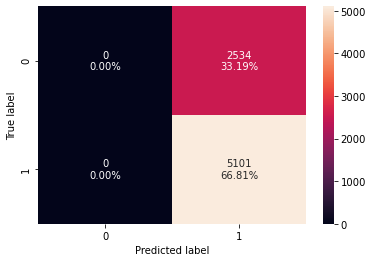

```python
#Calculating different metrics
dtree_estimator_model_train_perf=model_performance_classification_sklearn(dtree_estimator,X_train,y_train)
print("Training performance:\n",dtree_estimator_model_train_perf)
dtree_estimator_model_test_perf=model_performance_classification_sklearn(dtree_estimator,X_test,y_test)
print("Testing performance:\n",dtree_estimator_model_test_perf)
#Creating confusion matrix
confusion_matrix_sklearn(dtree_estimator, X_test, y_test)
```

### Tuning Bagging Classifier

```python
# Choose the type of classifier.
bagging_estimator_tuned = BaggingClassifier(random_state=1)

# Grid of parameters to choose from
parameters = {'max_samples': [0.7,0.8,0.9,1],
              'max_features': [0.7,0.8,0.9,1],
              'n_estimators' : [10,20,30,40,50],
             }

# Type of scoring used to compare parameter combinations
acc_scorer = metrics.make_scorer(metrics.recall_score)

# Run the grid search
grid_obj = GridSearchCV(bagging_estimator_tuned, parameters, scoring=acc_scorer,cv=5)
grid_obj = grid_obj.fit(X_train, y_train)

# Set the clf to the best combination of parameters
bagging_estimator_tuned = grid_obj.best_estimator_

# Fit the best algorithm to the data.
bagging_estimator_tuned.fit(X_train, y_train)
```

```
BaggingClassifier(max_features=0.7, max_samples=1, n_estimators=30,
                  random_state=1)
```

```
Training performance:
    Accuracy  Recall  Precision        F1
0  0.668089     1.0   0.668089  0.801023
Testing performance:
    Accuracy  Recall  Precision        F1
0  0.668107     1.0   0.668107  0.801036
```

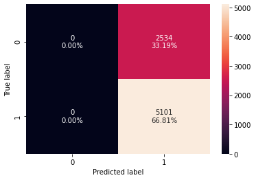

```python
#Calculating different metrics
bagging_estimator_tuned_model_train_perf=model_performance_classification_sklearn(bagging_estimator_tuned,X_train,y_train)
print("Training performance:\n",bagging_estimator_tuned_model_train_perf)
bagging_estimator_tuned_model_test_perf=model_performance_classification_sklearn(bagging_estimator_tuned,X_test,y_test)
print("Testing performance:\n",bagging_estimator_tuned_model_test_perf)

#Creating confusion matrix
confusion_matrix_sklearn(bagging_estimator_tuned, X_test, y_test)
```

- Similar results to the tuned Decision tree.

### Tuning Random Forest

```python
# Choose the type of classifier.
rf_tuned = RandomForestClassifier(class_weight={0:0.35,1:0.65},random_state=1)

parameters = {
                'max_depth': list(np.arange(3,10,1)),
                'max_features': np.arange(0.6,1.1,0.1),
                'max_samples': np.arange(0.7,1.1,0.1),
                #'min_samples_split': np.arange(2, 20, 5),
                'n_estimators': np.arange(30,160,20),
                #'min_impurity_decrease': [0.0001,0.001,0.01,0.1]
}


# Type of scoring used to compare parameter combinations
scorer = metrics.make_scorer(metrics.recall_score)

# Run the grid search
grid_obj = GridSearchCV(rf_tuned, parameters, scoring=scorer,cv=5,n_jobs=-1)
grid_obj = grid_obj.fit(X_train, y_train)

# Set the clf to the best combination of parameters
rf_tuned = grid_obj.best_estimator_

# Fit the best algorithm to the data.
rf_tuned.fit(X_train, y_train)
```

```
RandomForestClassifier(class_weight={0: 0.35, 1: 0.65}, max_depth=3,
                       max_features=0.6, max_samples=0.7, n_estimators=90,
                       random_state=1)
```

```
Training performance:
    Accuracy    Recall  Precision        F1
0  0.718561  0.953361   0.717902  0.819045
Testing performance:
    Accuracy    Recall  Precision        F1
0  0.713556  0.944717   0.716686  0.815053
```

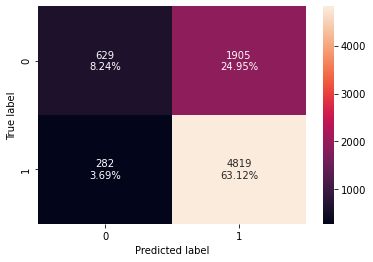

```python
#Calculating different metrics
rf_tuned_model_train_perf=model_performance_classification_sklearn(rf_tuned,X_train,y_train)
print("Training performance:\n",rf_tuned_model_train_perf)
rf_tuned_model_test_perf=model_performance_classification_sklearn(rf_tuned,X_test,y_test)
print("Testing performance:\n",rf_tuned_model_test_perf)

#Creating confusion matrix
confusion_matrix_sklearn(rf_tuned, X_test, y_test)
```

- Overfitting has been lowered.
- Accuracy has been improved with the Random Forest compared to Decision Tree and Bagging.
- F1 scores and Recall are good.

### Adaboost

```
   Accuracy   Recall  Precision        F1
0  0.740568  0.89084   0.761402  0.821051
   Accuracy    Recall  Precision        F1
0  0.733857  0.877475   0.760836  0.815004
```

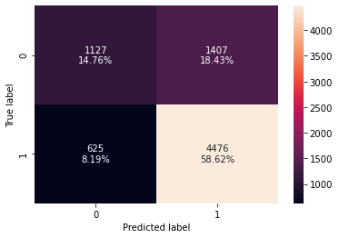

```python
#Fitting the model
ab_classifier = AdaBoostClassifier(random_state=1)
ab_classifier.fit(X_train,y_train)

#Calculating different metrics
ab_classifier_model_train_perf=model_performance_classification_sklearn(ab_classifier,X_train,y_train)
print(ab_classifier_model_train_perf)
ab_classifier_model_test_perf=model_performance_classification_sklearn(ab_classifier,X_test,y_test)
print(ab_classifier_model_test_perf)

#Creating confusion matrix
confusion_matrix_sklearn(ab_classifier,X_test,y_test)
```

- Results have improved over the tuned Random Forest in regards to increasing our model accuracy.
- F1 scores are still little low, but model is not overfitting the data to much.

### AdaBoost Hyperparameter Tuning

```python
# Choose the type of classifier.
abc_tuned = AdaBoostClassifier(random_state=1)

# Grid of parameters to choose from
parameters = {
    #Let's try different max_depth for base_estimator
    "base_estimator":[DecisionTreeClassifier(max_depth=1),DecisionTreeClassifier(max_depth=2),
                      DecisionTreeClassifier(max_depth=3)],
    "n_estimators": np.arange(10,110,10),
    "learning_rate":np.arange(0.1,2,0.1)
}

# Type of scoring used to compare parameter  combinations
scorer = metrics.make_scorer(metrics.f1_score)

# Run the grid search
grid_obj = GridSearchCV(abc_tuned, parameters, scoring=scorer,cv=5)
grid_obj = grid_obj.fit(X_train, y_train)

# Set the clf to the best combination of parameters
abc_tuned = grid_obj.best_estimator_

# Fit the best algorithm to the data.
abc_tuned.fit(X_train, y_train)
```

```
AdaBoostClassifier(base_estimator=DecisionTreeClassifier(max_depth=3),
                   learning_rate=0.4, n_estimators=10, random_state=1)
```

```
   Accuracy   Recall  Precision        F1
0  0.745509  0.89916   0.762488  0.825203
   Accuracy    Recall  Precision        F1
0  0.738441  0.888453   0.760403  0.819456
```

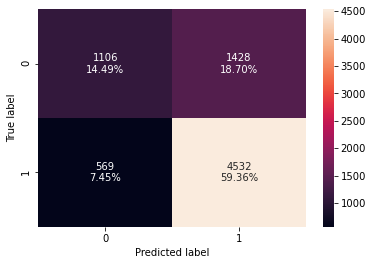

```python
#Calculating different metrics
abc_tuned_model_train_perf=model_performance_classification_sklearn(abc_tuned,X_train,y_train)
print(abc_tuned_model_train_perf)
abc_tuned_model_test_perf=model_performance_classification_sklearn(abc_tuned,X_test,y_test)
print(abc_tuned_model_test_perf)

#Creating confusion matrix
confusion_matrix_sklearn(abc_tuned,X_test,y_test)
```

- Results similar to tuned Random Forest and regular AdaBoost results.

### Gradient Boosting Model

```
Training performance:
    Accuracy    Recall  Precision        F1
0  0.757242  0.880504   0.783109  0.828956
Testing performance:
    Accuracy    Recall  Precision       F1
0   0.74761  0.867869   0.779401  0.82126
```

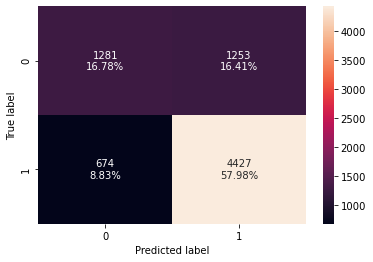

```python
#Fitting the model
gb_classifier = GradientBoostingClassifier(random_state=1)
gb_classifier.fit(X_train,y_train)

#Calculating different metrics
gb_classifier_model_train_perf=model_performance_classification_sklearn(gb_classifier,X_train,y_train)
print("Training performance:\n",gb_classifier_model_train_perf)
gb_classifier_model_test_perf=model_performance_classification_sklearn(gb_classifier,X_test,y_test)
print("Testing performance:\n",gb_classifier_model_test_perf)

#Creating confusion matrix
confusion_matrix_sklearn(gb_classifier,X_test,y_test)
```

- Gradient Boosting has highest test F1 score and still comparable metrics between training and test data.

### Gradient Boosting Hyperparameter Tuning

```python
# Choose the type of classifier.
gbc_tuned = GradientBoostingClassifier(init=AdaBoostClassifier(random_state=1),random_state=1)

# Grid of parameters to choose from
parameters = {
    "n_estimators": [100,150,200,250],
    "subsample":[0.8,0.9,1],
    "max_features":[0.7,0.8,0.9,1]
}

# Type of scoring used to compare parameter combinations
scorer = metrics.make_scorer(metrics.f1_score)

# Run the grid search
grid_obj = GridSearchCV(gbc_tuned, parameters, scoring=scorer,cv=5)
grid_obj = grid_obj.fit(X_train, y_train)

# Set the clf to the best combination of parameters
gbc_tuned = grid_obj.best_estimator_

# Fit the best algorithm to the data.
gbc_tuned.fit(X_train, y_train)
```

```
GradientBoostingClassifier(init=AdaBoostClassifier(random_state=1),
                           max_features=0.7, random_state=1, subsample=0.8)
```

```
Training performance:
    Accuracy   Recall  Precision        F1
0  0.757018  0.87916   0.783553  0.828608
Testing performance:
    Accuracy    Recall  Precision       F1
0  0.748003  0.865517   0.781001  0.82109
```

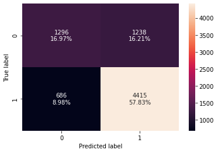

```python
#Calculating different metrics
gbc_tuned_model_train_perf=model_performance_classification_sklearn(gbc_tuned,X_train,y_train)
print("Training performance:\n",gbc_tuned_model_train_perf)
gbc_tuned_model_test_perf=model_performance_classification_sklearn(gbc_tuned,X_test,y_test)
print("Testing performance:\n",gbc_tuned_model_test_perf)

#Creating confusion matrix
confusion_matrix_sklearn(gbc_tuned,X_test,y_test)
```

- Boosting did not improve the model in a very meaningful way

### XGB Boosting Classifier

```
Training performance:
    Accuracy    Recall  Precision        F1
0  0.832922  0.928151   0.838903  0.881273
Testing performance:
    Accuracy    Recall  Precision        F1
0  0.730452  0.851206   0.769722  0.808416
```

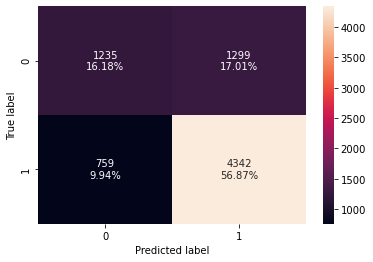

```python
#Fitting the model
xgb_classifier = XGBClassifier(random_state=1, eval_metric='logloss')
xgb_classifier.fit(X_train,y_train)

#Calculating different metrics
xgb_classifier_model_train_perf=model_performance_classification_sklearn(xgb_classifier,X_train,y_train)
print("Training performance:\n",xgb_classifier_model_train_perf)
xgb_classifier_model_test_perf=model_performance_classification_sklearn(xgb_classifier,X_test,y_test)
print("Testing performance:\n",xgb_classifier_model_test_perf)

#Creating confusion matrix
confusion_matrix_sklearn(xgb_classifier,X_test,y_test)
```